# Part 3: Functional Enrichment

Stephanie Hickey

2023-10-25

## Set Up

### Load necessary libraries

```r
library(tidyverse)
library(DT)
library(patchwork)
library(fgsea)
library(GO.db)
library(RColorBrewer)
conflicted::conflict_prefer(name = "filter", winner = "dplyr")
```

```
## [conflicted] Removing existing preference.
## [conflicted] Will prefer dplyr::filter over any other package.
```

```r
conflicted::conflict_prefer(name = "select", winner = "dplyr")
```

```
## [conflicted] Removing existing preference.
## [conflicted] Will prefer dplyr::select over any other package.
```

```r
conflicted::conflict_prefer(name = "desc", winner = "dplyr")
```

```
## [conflicted] Removing existing preference.
## [conflicted] Will prefer dplyr::desc over any other package.
```

```r
conflicted::conflict_prefer(name = "rename", winner = "dplyr")
```

```
## [conflicted] Removing existing preference.
## [conflicted] Will prefer dplyr::rename over any other package.
```

```r
set.seed(1) # to make sure that we get the same results for randomization
```

### Set your project paths in advance

```r
# tells us which directory we're currently in
# if you opened Rstudio by clicking `RNA-seq_RRM_2023.Rproj`
# you should already be in the `RNA-seq_RRM_2023` directory
getwd()
```

```
## [1] "/Users/stephanielepp/Desktop/repos/workshops/RNA-seq_RRM_2023"
```

```r
# if not use `setwd()` to set the working directory to `RNA-seq_RRM_2023`
# setwd("path/to/RNA-seq_RRM_2023")
project_path <- getwd()

# make a new folder called "part3_results" for the results
# make an object holding folder name
part3_results <- paste0(project_path, "/part3_results")
# only make the folder if a folder by that name DOES NOT already exist
if(!dir.exists(part3_results)){dir.create(part3_results)}
```

### Load the data

**Gene association file**

Associates genes with GO terms. There are 17 columns, and you can find the descriptions [here](https://geneontology.org/docs/go-annotation-file-gaf-format-2.1/). We’ll only focus on these columns:

3. `DB Object Symbol`: Gene symbol
4. `Qualifier`: Tells how the gene is related to the Gene ontology category
5. `GO ID`: Gene ontology category ID

Also interesting:

7. [`Evidence code`](https://geneontology.org/docs/guide-go-evidence-codes/): Each annotation includes an evidence code to indicate how the annotation to a particular term is supported. Evidence codes fall into several categories:
   - Inferred from Experiment (EXP)
   - Inferred from Direct Assay (IDA)
   - Inferred from Physical Interaction (IPI)
   - Inferred from Mutant Phenotype (IMP)
   - Inferred from Genetic Interaction (IGI)
   - Inferred from Expression Pattern (IEP)
   - Inferred from High Throughput Experiment (HTP)
   - Inferred from High Throughput Direct Assay (HDA)
   - Inferred from High Throughput Mutant Phenotype (HMP)
   - Inferred from High Throughput Genetic Interaction (HGI)
   - Inferred from High Throughput Expression Pattern (HEP)
8. `Aspect`: The specific ontology the term belongs to. For example, human “cytochrome c” can be described by the *molecular function* oxidoreductase activity, the *biological process* oxidative phosphorylation, and the *cellular component* mitochondrial intermembrane space. If you are only interested in categories belonging to one of these, you can filter for them.
   - P (biological process)
   - F (molecular function)
   - C (cellular component)

```r
# gene association file
gaf <- read_tsv(file = "data/goa_human.gaf", comment = "!", col_names = FALSE)
```

**DESeq2 results**

From Part 2: `part2_results/deseq2_results.txt`

```r
deres <- read_delim(file = "part2_results/deseq2_results.txt", delim = " ")
```

## Gene set enrichment analysis

Gene Set Enrichment Analysis (GSEA) is a computational method used to determine whether a predefined set of genes, known as a gene set, is significantly overrepresented among genes at the top and bottom of a list of genes ranked by some metric of interest, compared to what would be expected by chance. Check out [Subramanian *et al*. 2005](https://doi.org/10.1073/pnas.0506580102) for an in depth explanation.

Here, the gene sets are genes associated with gene ontology terms, and the genes are ranked by the Wald statistic, `stat`, from DESeq2, which is equal to `log2(FoldChange)/standard error`.

### `.gaf` file manipulation

**What we need:**

A list object where each element is a vector of gene names corresponding to a gene ontology category.

**How to get there**

1. Filter the `Qualifier` column in the gaf file for positive gene/term associations. We don’t care about “NOT” associations.
2. Select the `Gene` and `GOID` columns.
3. Use the `split()` function to split the data frame into a list of data frames by `GOID`
4. Use `lapply()` to change each data frame in the list to a vector of genes. Learn more about the `apply()` functions [here](https://ademos.people.uic.edu/Chapter4.html#1_what_are_apply_functions).

```r
# Make a list of genes annotated to go terms using the gaf
# filter out "NOT" relationships
gaf_list <-
  gaf %>%
  filter(!grepl("NOT", X4)) %>%  # filter out "NOT" relationships
  dplyr::select(X5, X3) %>%      # another package has a function called `select()`
  rename(GOID = "X5",            # rename() changes the column names
         Gene = "X3") %>%
  distinct() %>%
  dplyr::select(GOID, Gene) %>%
  split(as.factor(.$GOID))       # split the df into a list by GOID
                                 # because `split()` is not a tidyverse function
                                 # we need to used .$ to refer to the GOID column

gaf_list[[1]]                    # access the first element of the list
```

```
## # A tibble: 11 × 2
##    GOID       Gene
##    <chr>      <chr>
##  1 GO:0000002 OPA1
##  2 GO:0000002 SLC25A4
##  3 GO:0000002 TYMP
##  4 GO:0000002 LONP1
##  5 GO:0000002 MPV17
##  6 GO:0000002 MEF2A
##  7 GO:0000002 SLC25A36
##  8 GO:0000002 MGME1
##  9 GO:0000002 SLC25A33
## 10 GO:0000002 PIF1
## 11 GO:0000002 AKT3
```

```r
gaf_list[[2]]                    # access the second element of the list
```

```
## # A tibble: 4 × 2
##   GOID       Gene
##   <chr>      <chr>
## 1 GO:0000003 MMP23B
## 2 GO:0000003 LIN9
## 3 GO:0000003 GNRH2
## 4 GO:0000003 GNRH1
```

```r
length(gaf_list)                 # how many list elements?
```

```
## [1] 18695
```

```r
head(names(gaf_list))            # names of the list elements
```

```
## [1] "GO:0000002" "GO:0000003" "GO:0000009" "GO:0000010" "GO:0000012"
## [6] "GO:0000014"
```

```r
# make a list of vectors containing the genes instead of a list of data frames
class(gaf_list[[1]])
```

```
## [1] "tbl_df"     "tbl"        "data.frame"
```

```r
go_list <- lapply(gaf_list, function(x) {y = x$Gene; y})

class(go_list[[1]])
```

```
## [1] "character"
```

```r
# look at the first few list elements
head(go_list)
```

```
## $`GO:0000002`
##  [1] "OPA1"     "SLC25A4"  "TYMP"     "LONP1"    "MPV17"    "MEF2A"
##  [7] "SLC25A36" "MGME1"    "SLC25A33" "PIF1"     "AKT3"
##
## $`GO:0000003`
## [1] "MMP23B" "LIN9"   "GNRH2"  "GNRH1"
##
## $`GO:0000009`
## [1] "PIGV"  "ALG12"
##
## $`GO:0000010`
## [1] "PDSS1" "PDSS2"
##
## $`GO:0000012`
##  [1] "TNP1"   "XRCC1"  "LIG4"   "ERCC6"  "ERCC8"  "XNDC1N" "APTX"   "APLF"
##  [9] "SIRT1"  "TDP1"
##
## $`GO:0000014`
##  [1] "POLQ"    "ERCC1"   "MRE11"   "SETMAR"  "RAD50"   "DCLRE1C" "RBBP8"
##  [8] "ERCC4"   "ENDOG"   "EXOG"
```

```r
# names carry over from gaf_list
head(names(go_list)) # names carry over from gaf_list
```

```
## [1] "GO:0000002" "GO:0000003" "GO:0000009" "GO:0000010" "GO:0000012"
## [6] "GO:0000014"
```

### GSEA with `fgsea`

We need to make a vector of all of the genes from the DESeq2 results ranked by the Wald statistic, `stat`.

```r
# make a vector of genes ranked by stat
DEranks <-
  deres %>%
  filter(!is.na(padj)) %>%       # remove genes with no calculated padj
  select(Gene, stat) %>%         # select Gene and stat cols
  arrange(stat) %>%              # ranks the genes by stat
  deframe()                      # turns the data frame into a named vector

head(DEranks)
```

```
##      NOS1     RNF43      FASN      BCHE      CHP2     MYH14
## -22.42478 -21.10260 -19.32964 -16.34607 -15.46826 -15.23353
```

```r
tail(DEranks)
```

```
##   FCGR3A     CD86 IGHV3-74   FCGR1A   SECTM1    CXCR4
## 20.74092 21.03086 21.18959 21.28596 23.12422 23.24036
```

```r
# perform GSEA analysis
fgseaRes <- fgsea(pathways = go_list,
                  stats    = DEranks,
                  minSize  = 10,      # smallest goterm to consider
                  maxSize  = 500)     # largest goterm to consider
head(fgseaRes)
```

```
##       pathway      pval      padj    log2err         ES        NES size
## 1: GO:0000002 0.5212224 0.7960362 0.06863256  0.4159905  0.9721756   11
## 2: GO:0000027 0.1297710 0.3983265 0.19782202 -0.4580102 -1.3442651   18
## 3: GO:0000028 0.8361858 0.9775070 0.06335970 -0.2725717 -0.7243732   13
## 4: GO:0000030 0.2935065 0.6157741 0.12814292 -0.3991895 -1.1453046   17
## 5: GO:0000038 0.1246753 0.3896452 0.20429476 -0.4722588 -1.3549459   17
## 6: GO:0000045 0.6377205 0.8741818 0.04850598  0.2632972  0.8946257   62
##                                   leadingEdge
## 1:                            TYMP,MPV17,PIF1
## 2:     RPL5,RPL24,RPL11,MDN1,RPLP0,RPL23A,...
## 3:               RPS28,RPS5,ERAL1,RPS15,RPS14
## 4: PIGZ,TMTC3,TMTC2,DPY19L4,TMTC1,DPY19L2,...
## 5: ABCD3,ACOT2,CYP4F12,ACOX1,ACSBG1,ACOX2,...
## 6:     TCIRG1,RUFY4,RAB43,VMP1,CTSD,WIPI1,...
```

**Column descriptions**

- `pathway` – name of the pathway as in ’names(pathway)’; here it’s the GOID
- `pval` – an enrichment p-value
- `padj` – a BH-adjusted p-value
- `log2err` – the expected error for the standard deviation of the P-value logarithm
- `ES` – enrichment score, reflects the degree to which the genes in a gene set are overrepresented at the top or bottom of the entire ranked list of genes,
  - $ES>0$ means the genes are enriched among up-regulated genes
  - $ES<0$ means the genes are enriched among down-regulated genes
- `NES` – enrichment score normalized to mean enrichment of random samples of the same size
- `size` – size of the pathway after removing genes not present in ’names(DEranks)‘
- `leadingEdge` – leading edge genes that drive the enrichment

### Reformat the results table

Use the GO.db package to get the descriptions that matching the GOIDs. Later, we’ll add this to the results table using `left_join()`

```r
# extract all go term descriptions from the GO.db package
goterms <- as.data.frame(Term(GOTERM))

# change column name
colnames(goterms) <- "GOTerm"

# make the rownames into a column called `GOID`
goterms$GOID <- rownames(goterms)

head(goterms)
```

```
##                                                              GOTerm
## GO:0000001                                mitochondrion inheritance
## GO:0000002                         mitochondrial genome maintenance
## GO:0000003                                             reproduction
## GO:0000006    high-affinity zinc transmembrane transporter activity
## GO:0000007 low-affinity zinc ion transmembrane transporter activity
## GO:0000009                   alpha-1,6-mannosyltransferase activity
##                  GOID
## GO:0000001 GO:0000001
## GO:0000002 GO:0000002
## GO:0000003 GO:0000003
## GO:0000006 GO:0000006
## GO:0000007 GO:0000007
## GO:0000009 GO:0000009
```

Change the format of the `leadingEdge` from a list of character vectors to a vector of strings with `sapply()` and `toString()`

```r
# leading edge is a list of character vectors, where each row is a list element
class(fgseaRes$leadingEdge)
```

```
## [1] "list"
```

```r
fgseaRes$leadingEdge[[1]]
```

```
## [1] "TYMP"  "MPV17" "PIF1"
```

```r
# we can only print cells in our data frame with length = 1
length(fgseaRes$leadingEdge[[1]])
```

```
## [1] 3
```

```r
# to print it as a tab delimited file, we need to change the column into one character vector
# so we'll put all of the genes into one string
# using toString() and sapply()

toString(fgseaRes$leadingEdge[[1]])
```

```
## [1] "TYMP, MPV17, PIF1"
```

```r
length(toString(fgseaRes$leadingEdge[[1]]))
```

```
## [1] 1
```

```r
# another example
fgseaRes$leadingEdge[[2]]
```

```
##  [1] "RPL5"   "RPL24"  "RPL11"  "MDN1"   "RPLP0"  "RPL23A" "MRPL20" "BRIX1"
##  [9] "RRS1"   "RPF2"   "NLE1"   "RPL6"   "MRTO4"  "PPAN"
```

```r
length(fgseaRes$leadingEdge[[2]])
```

```
## [1] 14
```

```r
toString(fgseaRes$leadingEdge[[2]])
```

```
## [1] "RPL5, RPL24, RPL11, MDN1, RPLP0, RPL23A, MRPL20, BRIX1, RRS1, RPF2, NLE1, RPL6, MRTO4, PPAN"
```

```r
length(toString(fgseaRes$leadingEdge[[2]]))
```

```
## [1] 1
```

```r
# format the results table
fgseaReform <-
  fgseaRes %>%
  mutate(leadingEdge = sapply(leadingEdge, toString),      # change leadingEdge from list to character vector
         leadingEdgeSize = str_count(leadingEdge, "\\S+"), # count the number of leadingEdge genes
         Regulation = case_when(                           # add a `Regulation` column
           NES < 0 ~ "down-regulated",
           NES > 0 ~ "up-regulated")) %>%
         rename(GOID = "pathway") %>%
         left_join(goterms) %>%                            # add a column with the go term descriptions using left_join()
         relocate(GOTerm, .after = GOID)  %>%              # move GOTerm to after GOID
         arrange(padj)
head(fgseaReform)
```

```
##          GOID                   GOTerm         pval         padj  log2err
## 1: GO:0002250 adaptive immune response 1.000000e-50 1.723500e-47       NA
## 2: GO:0006955          immune response 1.000000e-50 1.723500e-47       NA
## 3: GO:0003823          antigen binding 8.300556e-38 9.537339e-35 1.602431
## 4: GO:0006954    inflammatory response 5.157405e-35 4.444393e-32 1.536459
## 5: GO:0019814   immunoglobulin complex 2.556329e-34 1.762333e-31 1.522922
## 6: GO:0045087   innate immune response 6.586980e-33 3.784220e-30 1.488540
##           ES      NES size
## 1: 0.8245767 3.210824  201
## 2: 0.7791263 3.125125  288
## 3: 0.8782076 3.096086   80
## 4: 0.6453981 2.599578  311
## 5: 0.8902836 3.065026   67
## 6: 0.6234247 2.529446  346
##                                                                                                                                                                                                                                                                                                          …
## 1:                                                                                                                                                                                                                                                          CD86, IGLV2-14, SLAMF7, JCHAIN, IGKC, IGLV3-1…
## 2: CXCR4, SECTM1, FCGR1A, CD86, FCGR3A, IGLV2-14, CCR5, JCHAIN, IGKC, IGLV3-1, IGKV3-20, C5AR1, IGKV1D-39, IGLV1-44, IGKV1-17, CXCR6, CD96, VAV1, HLA-A, PTAFR, IGKV4-1, PIK3R5, IGHV3-33, RGS1, IGKV1-5, IGLV2-23, IGKV3-15, TRBC1, ADAMDEC1, IL2RG, IGKV1D-33, IL2RA, HLA-DRA, CD80, IGLV2-8, IGHV1-46,…
## 3:                                                                                                                                                                                                                                                                                                       …
## 4:                                                                                                                                                                                                                                                                                                       …
## 5:                                                                                                                                                                                                                                                                                                       …
## 6:                                                                                                                                                                                                                                                                                                       …
##    leadingEdgeSize   Regulation
## 1:             151 up-regulated
## 2:             185 up-regulated
## 3:              74 up-regulated
## 4:             158 up-regulated
## 5:              66 up-regulated
## 6:             157 up-regulated
```

```r
write_delim(fgseaReform, file = paste(part3_results,  "fgsea_results.csv", sep = "/"))

# make interactive table
fgseaTab <-
  fgseaReform %>%
  filter(padj < .05) %>%
  dplyr::select(-pval,
                -log2err,
                -ES,
                -NES,
                -leadingEdgeSize,
                -size) %>%
  mutate(Regulation = as.factor(Regulation),
         padj = format(padj, digits=3))

datatable(fgseaTab, rownames = FALSE, filter = "top")
```

| GOID | GOTerm | padj | leadingEdge | Regulation |
| --- | --- | --- | --- | --- |
| GO:0002250 | adaptive immune response | 1.72e-47 | CD86, IGLV2-14, SLAMF7, JCHAIN, IGKC, IGLV3-1, JAK3, IGKV3-20, IGKV1D-39, IGLV1-44, IGHG1, IGKV1-17, IGKV4-1, CD3G, IGKV1-5, IGLV2-23, IGKV3-15, LILRB1, TRBC1, CD79A, IGKV1D-33, LILRB4, HLA-DRA, EOMES… | up-regulated |
| GO:0006955 | immune response | 1.72e-47 | CXCR4, SECTM1, FCGR1A, CD86, FCGR3A, IGLV2-14, CCR5, JCHAIN, IGKC, IGLV3-1, IGKV3-20, C5AR1, IGKV1D-39, IGLV1-44, IGKV1-17, CXCR6, CD96, VAV1, HLA-A, PTAFR, IGKV4-1, PIK3R5, IGHV3-33, RGS1, IGKV1-5, I… | up-regulated |
| GO:0003823 | antigen binding | 9.54e-35 | IGHV3-74, IGLV2-14, JCHAIN, IGKC, IGLV3-1, IGKV3-20, IGHV1-18, IGKV1D-39, IGLV1-44, IGHG1, IGKV1-17, IGLC2, IGLL5, IGKV4-1, IGHV3-33, IGKV1-5, IGLV2-23, IGKV3-15, IGKV1D-33, IGLV2-8, IGHV1-46, IGHV1-6… | up-regulated |
| GO:0006954 | inflammatory response | 4.44e-32 | CXCR4, CCR5, THEMIS2, IDO1, GBP5, ITGAL, CLEC7A, C5AR1, CXCR6, CXCL9, ADAM8, CD96, CCL5, PTAFR, CCL8, HCK, IL2RA, IL6, PRKCQ, ITGB2, CXCL10, RELB, AIM2, LY86, SLC11A1, TLR1, PIK3CD, PIK3CG, FPR1, FPR3… | up-regulated |
| GO:0019814 | immunoglobulin complex | 1.76e-31 | IGHV3-74, IGLV2-14, IGLV3-1, IGHV1-18, IGKV1D-39, IGLV1-44, IGKV1-17, IGKV4-1, IGHV3-33, IGKV1-5, IGLV2-23, IGKV3-15, IGKV1D-33, IGLV2-8, IGHV1-46, IGHV1-69-2, IGKV3-11, IGHV4-59, IGKV3D-11, IGLV1-51,… | up-regulated |
| GO:0045087 | innate immune response | 3.78e-30 | FCGR1A, JCHAIN, CLEC4E, JAK3, GBP1, HLA-A, MMP3, HCK, RNF166, APOL1, FCER1G, C2, RELB, AIM2, SIGLEC10, LY86, TLR1, PIK3CD, IGHM, PIK3CG, PARP9, TLR8, LCK, APOBEC3G, IFI6, CORO1A, LYN, UBE2L6, NLRC5, Z… | up-regulated |
| GO:0009897 | external side of plasma membrane | 1.08e-29 | CXCR4, FCGR1A, CD86, FCGR3A, SLAMF7, CCR5, IL21R, CLEC4E, CTSB, CD2, ITGAL, CXCR6, CXCL9, HLA-A, CD3G, LILRB1, CD79A, IL2RG, IL2RA, CD80, PTPRC, ITGB2, CXCL10, FCER1G, CSF2RB, CD27, TLR8, PDCD1LG2, MI… | up-regulated |
| GO:0016064 | immunoglobulin mediated immune response | 3.17e-22 | IGHV3-74, IL21R, IGKC, IGHV1-18, IGLC2, IGLL5, IGHV3-33, IGHV1-46, FCER1G, CSF2RB, IGHV1-69-2, IGHV4-59, CD27, IGHV5-51, TLR8, IGHV3-23, IGHV1-2, IGHV3-11, IGHV6-1, CD74, IGHV3-15, IGHV2-5, IGHV3-48, … | up-regulated |
| GO:0051607 | defense response to virus | 1.03e-19 | GBP5, GBP1, CXCL9, LILRB1, PTPRC, IL6, STAT1, IRF1, AIM2, UNC13D, PARP9, TLR8, APOBEC3G, OAS2, IFI6, NLRC5, APOBEC3A, ITGAX, GBP3, PRF1, RTP4, IFNG, CARD9, IKBKE, PLSCR1, MLKL, IRF7, DTX3L, STAT2, RNA… | up-regulated |
| GO:0071222 | cellular response to lipopolysaccharide | 1.15e-17 | CD86, CCR5, GBP5, CXCL9, KMO, MMP3, LILRB1, CD80, IL6, CXCL10, GFI1, IL24, PDCD1LG2, ARID5A, LITAF, GBP3, TNFRSF1B, CXCL1, CD68, IRF8, LILRB2, HAVCR2, NLRP3, CD274, IRAK3, SBNO2, GBP2, SERPINE1, CD40,… | up-regulated |

[output cut: 429 more lines]

## Plot results

- Check how many GO terms are significantly enriched for up- or down-regulated genes
- Make separate bubble plots for terms enriched for up- or down-regulated genes with:
  - The top 10 terms by padj on the y-axis
  - The `NES` on the x-axis
  - A “bubble” for each term colored by `-log10(padj)` and sized by `leadingEdgeSize`

```r
# How many significant terms are there?
fgseaReform %>%
  filter(padj < .05) %>%      # filter for significantly enriched terms
  group_by(Regulation) %>%    # group the rows by `Regulation`
  tally()                     # count the rows in each group
```

```
## # A tibble: 2 × 2
##   Regulation         n
##   <chr>          <int>
## 1 down-regulated   117
## 2 up-regulated     322
```

```r
# make a color palette
sequential_pal <- colorRampPalette(brewer.pal(n = 9, name ="YlOrRd"))(20)
# remove the lightest colors because they are hard to see
sequential_pal_dark <- sequential_pal[5:20]

# find the terms of interest
down_oi <-
  fgseaReform %>%
    filter(Regulation == "down-regulated") %>%
    slice_min(order_by=padj, n=10) %>%
    pull(GOTerm)

  up_oi <-
  fgseaReform %>%
    filter(Regulation == "up-regulated") %>%
    slice_min(order_by=padj, n=10) %>%
    pull(GOTerm)

# find the smallest and largest leadingEdgeSize among the terms of interest
small_edge =
  fgseaReform %>%
  filter(GOTerm %in% c(down_oi, up_oi)) %>%
  pull(leadingEdgeSize) %>%
  min()

small_edge
```

```
## [1] 20
```

```r
large_edge =
  fgseaReform %>%
  filter(GOTerm %in% c(down_oi, up_oi)) %>%
  pull(leadingEdgeSize) %>%
  max()

large_edge
```

```
## [1] 185
```

```r
# find the highest and lowest -log10(padj) among the terms of interest
high_adj =
  fgseaReform %>%
  filter(GOTerm %in% c(down_oi, up_oi)) %>%
  mutate(log_padj = -log10(padj)) %>%
  pull(log_padj) %>%
  max() %>%
  ceiling() # rounds up to closest whole number

high_adj
```

```
## [1] 47
```

```r
low_adj =
  fgseaReform %>%
  filter(GOTerm %in% c(down_oi, up_oi)) %>%
  mutate(log_padj = -log10(padj)) %>%
  pull(log_padj) %>%
  min() %>%
  floor() # rounds down to closest whole number

low_adj
```

```
## [1] 4
```

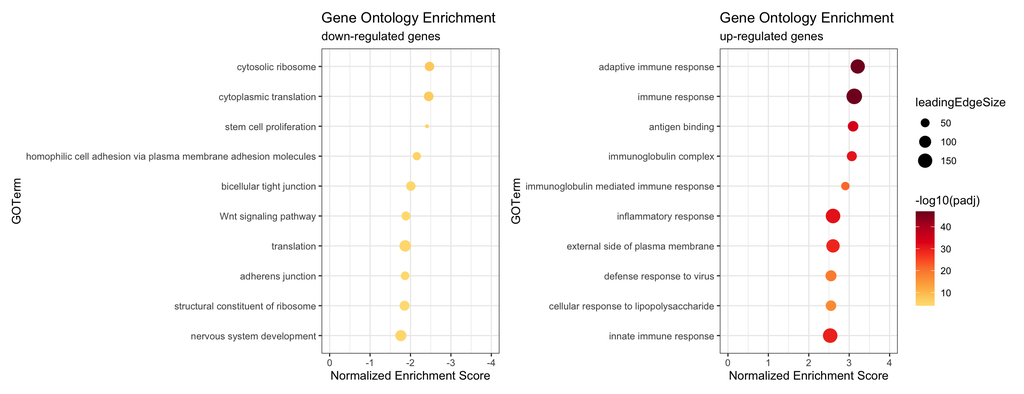

```r
# plot
plot_down_terms <-
  fgseaReform %>%
    filter(Regulation == "down-regulated") %>%            # filter for terms enriched with down-regulated genes
    slice_min(order_by=padj, n=10) %>%                    # select the terms with the 10 lowest padj
    mutate(GOTerm = fct_reorder(GOTerm, desc(NES))) %>%   # order the terms by NES for the plot
    ggplot(aes(x=NES,
               y=GOTerm,
               size=leadingEdgeSize,                      # size of the bubble = leadingEdgeSize
               color = -log10(padj))) +                   # color the bubble by -log10(padj)
      geom_point() +                                      # make a dot (bubble) plot
      xlim(0,-4) +
      lims(size = c(small_edge,large_edge)) +              # force the size limits to between small_edge and large_edge
      scale_color_gradientn(colours = sequential_pal_dark, # use the sequential_pal_dark to color the bubbles
                            limits= c(low_adj,high_adj)) + # force the color key to go from low_adj to high_adj
      labs(title="Gene Ontology Enrichment",
           subtitle = "down-regulated genes") +
      xlab("Normalized Enrichment Score") +
      theme_bw()

plot_up_terms <-
  fgseaReform %>%
    filter(Regulation == "up-regulated") %>%
    slice_min(order_by=padj, n=10) %>%
    mutate(GOTerm = fct_reorder(GOTerm, NES)) %>%
    ggplot(aes(x=NES, y=GOTerm,
               size=leadingEdgeSize,
               color = -log10(padj))) +
      geom_point() +
      xlim(0,4) +
      lims(size = c(small_edge,large_edge)) +
      scale_color_gradientn(colours = sequential_pal_dark,
                            limits= c(low_adj,high_adj)) +
      labs(title="Gene Ontology Enrichment",
           subtitle = "up-regulated genes") +
      xlab("Normalized Enrichment Score") +
      theme_bw()

# patchwork magic to combine the two plots
both = (plot_down_terms | plot_up_terms) + plot_layout(guides = 'collect')
both
```

```r
ggsave(both, file = paste(part3_results, "goterm_bubble.png", sep = "/"), width=13, height=5)
```